# Lab 1: Linear models for quantitative genetics

BMI 206

Vishvak

10/18/24

### PART1: Analyzing provided genotype and phenotype data.

**Prepare the data.** Read in the genotype and phenotype matrices.

```r
genos = as.matrix(read.table("./genos.txt"))
phenos = as.matrix(read.table("./phenos.txt"))
```

Make a histogram of the phenotypes. Do they look normally distributed?

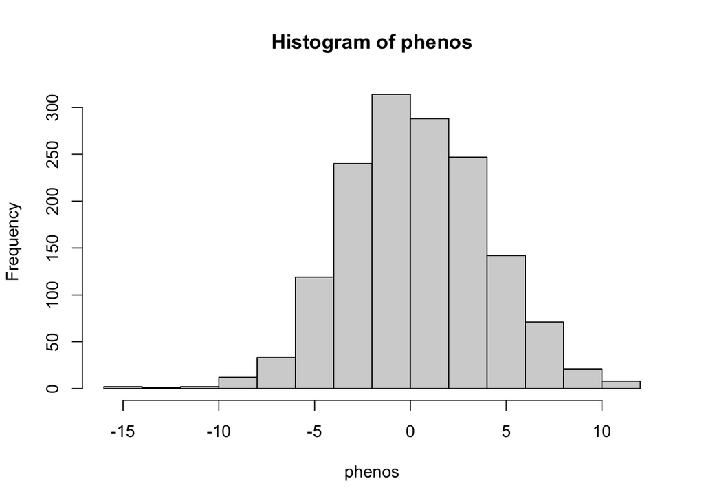

```r
hist(phenos)
```

*Yes they look normally distributed*

How are the genotypes encoded?

```r
table(genos)
```

```
## genos
##       0       1       2
## 4773842 5447131 4779027
```

*In terms of dosage of an allele, so 0 indicates homozygous, 1 indicates heterozygous and 2 indicates homozygous but w.r.t to the allele that we are “adding”*

How many individuals are there in the dataset and how many SNPs? (Save them in `N` and `M`, respectively.)

```r
dim(genos)
```

```
## [1]  1500 10000
```

```r
dim(phenos)
```

```
## [1] 1500    1
```

```r
N = 1500
M = 10000
```

*10k SNPs and 1500 people*

**Compute the *minor* allele frequency for every SNP. Check MAFs are <0.5.**

```r
MAFs = array(0,M)
for(i in 1:M) {
      #using dot product to get the allele counts per snp, we force the genos to be a factor with levels 0,1,2, because there is a case where there is a 0,1 and then the dot product does not work
      allele_counts = table(factor(genos[,i], levels = c(0,1,2)))
      a = sum(allele_counts * c(0, 1, 2))
      b = sum(allele_counts * c(2, 1, 0))
      MAFs[i] = min(b / (a + b), a / (a + b))
}

MAFs[1:10]
```

```
##  [1] 0.1516667 0.3226667 0.4126667 0.2156667 0.4626667 0.4826667 0.4863333
##  [8] 0.1516667 0.2990000 0.3310000
```

```r
max(MAFs)
```

```
## [1] 0.5
```

**Run a GWAS under an additive model and save the p-values, z-scores, and effect sizes.**

```r
pvalues = array(0,M)
zscores = array(0,M)
betas = array(0,M)
for(i in 1:M) {
    g = genos[,i]
    res = (lm(phenos ~ g))
    zscores[i] = summary(res)$coefficients[,3][["g"]]
    pvalues[i] = summary(res)$coefficients[,4][["g"]]
    betas[i] = summary(res)$coefficients[,1][["g"]]
}
```

Summarize the effect sizes.

```r
summary(betas)
```

```
##      Min.   1st Qu.    Median      Mean   3rd Qu.      Max.
## -3.400728 -0.105822  0.002475  0.004204  0.113524  2.245525
```

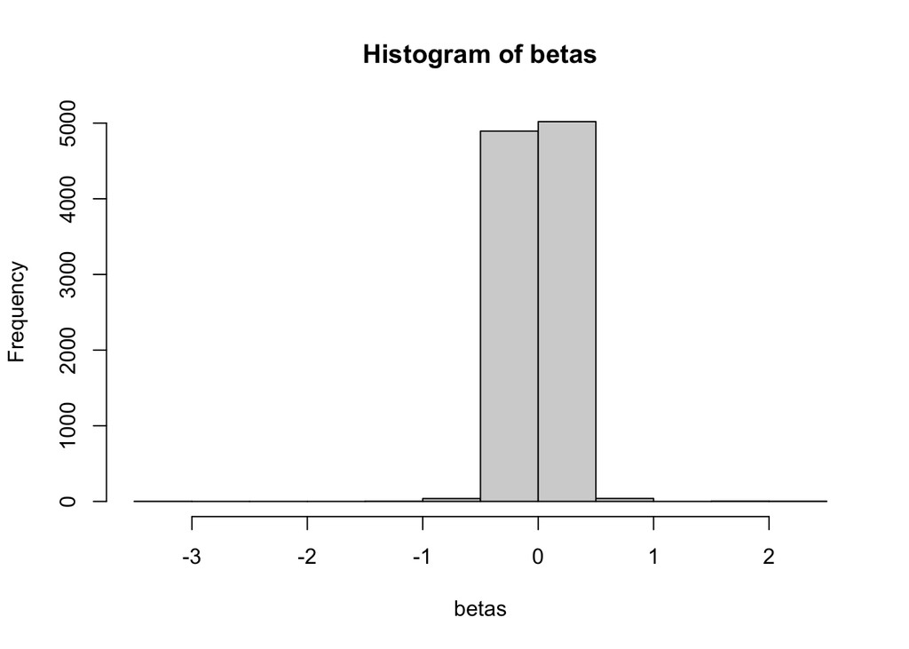

```r
hist(betas)
```

*Betas are normally distributed which is to be expected, as we intuit that there are only a few SNPs that are disease causing - this is also an assumption for getting a p-value for the Betas as well*

Are there any significantly associated SNPs? If so, which SNPs are they?

```r
length(which(pvalues<0.05))
```

```
## [1] 449
```

```r
pvalues = p.adjust(pvalues,method="bonferroni")
assoc = which(pvalues<0.05)
length(assoc)
```

```
## [1] 10
```

```r
assoc
```

```
##  [1]  1  2  3  4  5  6  7  8  9 10
```

*We have 10 significant SNPs after Bonferroni correction, 449 before*

How big are their effect sizes? How significant are they?

```r
range(betas[assoc])
```

```
## [1] -3.400728  2.245525
```

```r
range(zscores[assoc])
```

```
## [1] -21.02190  16.12821
```

```r
range(pvalues[assoc])
```

```
## [1] 3.488001e-82 6.308608e-03
```

*Effect sizes for the 10 SNPs include positive and negative coefficients, and they are also quite significant. The magnitude of |t| is also quite large indicating strong association. After we bonferroni correct, we are also selecting for the highest effect sizes as they are typically the most significant*

Draw a QQ plot for log10(p) values.

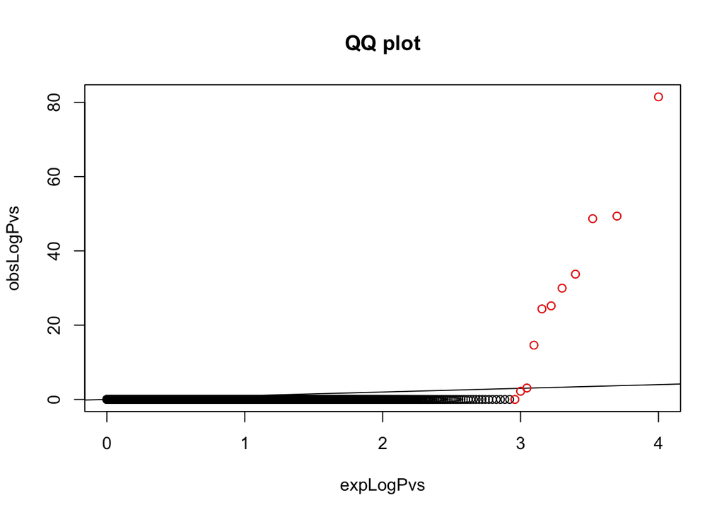

```r
obsLogPvs = sort(-log10(pvalues))
expLogPvs = sort(-log10(seq(1/M,1,1/M)))
plot(expLogPvs,obsLogPvs,main='QQ plot')
abline( a=0, b=1 )
#label the significant SNPs red
points(expLogPvs[(M-length(assoc)):M],obsLogPvs[(M-length(assoc)):M],col="red")
```

Is there inflation? Use the chi-square statistics to check.

```r
chis = zscores^2
lambdaGC = median(chis)/0.454 # why .454?
lambdaGC
```

```
## [1] 1.007873
```

```r
median(chis)
```

```
## [1] 0.4575746
```

*Here 0.454 is a genomic inflation factor given by qchisq(0.5,df=1), we are scaling our chis by a the median of a chisq distribution with degrees of freedom=1 as that is the minimum dof that we need to estimate our coefficients (I’m a little confused on why we are using the chisq test here to test for inflation as opposed to any other distribution that esitmates a “null effect”)*

Plot the phenotype predictions for the most significant SNP.

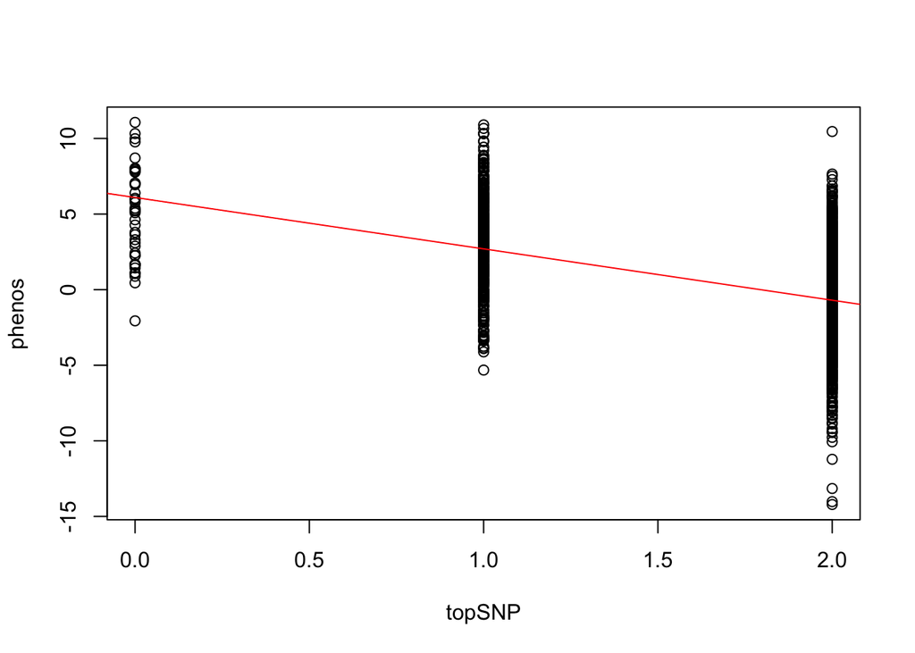

```r
topSNP = genos[,order(pvalues)[1]]
plot(topSNP,phenos)
abline(lm(phenos~topSNP)$coeff,col="red")
```

**Build a linear predictor of the phenotype using the associated SNPs.**

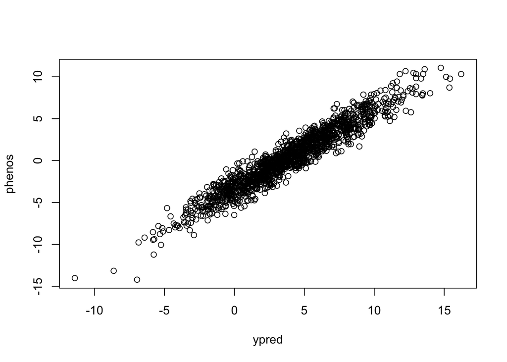

```r
ypred = array(0,N)
for(i in 1:N) {
      ypred[i] = genos[i,assoc] %*% betas[assoc]
}
plot(ypred,phenos)
```

What is the correlation between the predicted phenotype and the true phenotype?

```r
cor(ypred,phenos)
```

```
##             V1
## [1,] 0.9582865
```

*Very good correlation, so betas, without an intercept, are good predictors*

**BONUS: Test each of the associated SNPs for non-linearity.**

```r
library(ggplot2)
hp = array(0,length(assoc))
for (i in 1:length(assoc)) {
  g = genos[,assoc[i]]
  h = g
  #h[h==2]=0 #im not sure why we do this here, I don't want to model as dominant, non-domininant, I want to see if the addition of a SNP is non-linear
  lm_additive = lm(phenos ~ h)
  lm_quadratic = lm(phenos ~ h + I(h^2)) # quadratic, non-linear effect
  #Hint: can use anova(lm(?),lm(?)) or summary(lm(?))
  hp[i] <- anova( lm_additive, lm_quadratic ,test="Chisq")$Pr[2] #skip multiple test correction for now
}

hp
```

```
##  [1] 0.0008648828 0.9243775238 0.4973922086 0.1512578635 0.4853170766
##  [6] 0.1957158032 0.1199781814 0.1929036785 0.8697423061 0.4130710362
```

```r
anova(lm(phenos ~ genos[,assoc[1]]) , lm(phenos~genos[,assoc[1]] + I(genos[,assoc[1]]^2)))
```

```
## Analysis of Variance Table
##
## Model 1: phenos ~ genos[, assoc[1]]
## Model 2: phenos ~ genos[, assoc[1]] + I(genos[, assoc[1]]^2)
##   Res.Df   RSS Df Sum of Sq      F    Pr(>F)
## 1   1498 15720
## 2   1497 15604  1    115.66 11.097 0.0008859 ***
## ---
## Signif. codes:  0 '***' 0.001 '**' 0.01 '*' 0.05 '.' 0.1 ' ' 1
```

*The first snp seems to be differentially explained by including a non linear term. RSS decreases for Model 2, when we include a quadratic output, an additional 115.6 units of variance are explained and the F stat is quite high, but looking at the plot, the quadratic effect is not immediately apparent.*

BONUS: Visualize a linear SNP and a non-linear SNP.

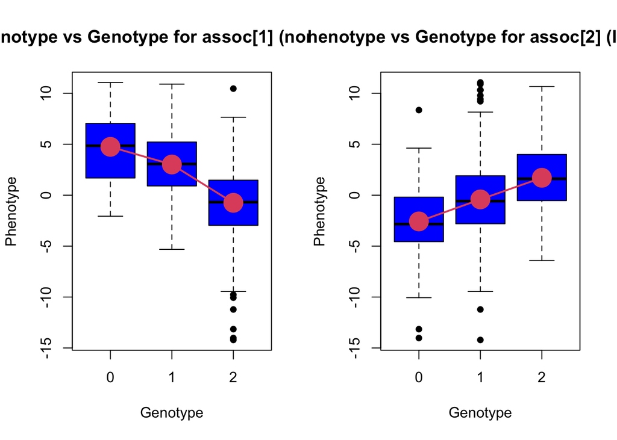

```r
par( mfrow=c(1,2) )
plot(factor(genos[,assoc[1]]), phenos,
     xlab = "Genotype",
     ylab = "Phenotype",
     main = "Phenotype vs Genotype for assoc[1] (non-linear)",
     col = "blue", pch = 16)
points(tapply(phenos, genos[, assoc[1]], mean), col = 2, pch = 16, cex = 3)
lines(tapply(phenos, genos[, assoc[1]], mean), col = 2, lwd = 2)

plot(factor(genos[,assoc[2]]), phenos,
     xlab = "Genotype",
     ylab = "Phenotype",
     main = "Phenotype vs Genotype for assoc[2] (linear)",
     col = "blue", pch = 16)
points( tapply(phenos, genos[, assoc[2]], mean), col = 2, pch = 16, cex = 3)
lines( tapply(phenos, genos[, assoc[2]], mean), col = 2, lwd = 2)
```

**Repeat the GWAS to test for recessive rather than additive genetic effects.**

```r
genos2 = genos
genos2[genos<1]=1
pvalues2 = array(0,M)
zscores2 = array(0,M)
betas2 = array(0,M)
for(i in 1:M) {
  g = genos2[,i]
    res = (lm(phenos ~ g))
    zscores2[i] = summary(res)$coefficients[,3][["g"]]
    pvalues2[i] = summary(res)$coefficients[,4][["g"]]
    betas2[i] = summary(res)$coefficients[,1][["g"]]
}
```

**Are the same SNPs significant or not?**

```r
pvalues2 = p.adjust(pvalues2,method="bonferroni")
assoc2 = which(pvalues2<0.05)
length(assoc2)
```

```
## [1] 9
```

```r
assoc2
```

```
## [1] 1 2 3 4 5 6 7 8 9
```

*1 Fewer significant SNP*

**How did the effect sizes change?**

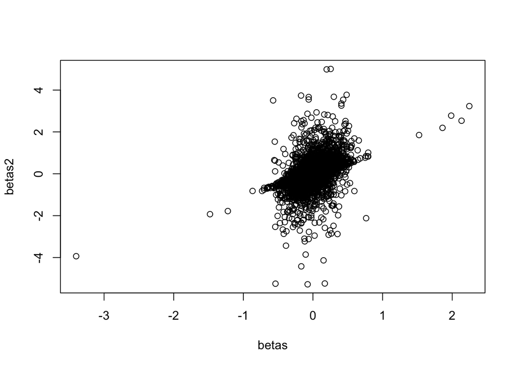

```r
plot(betas,betas2)
```

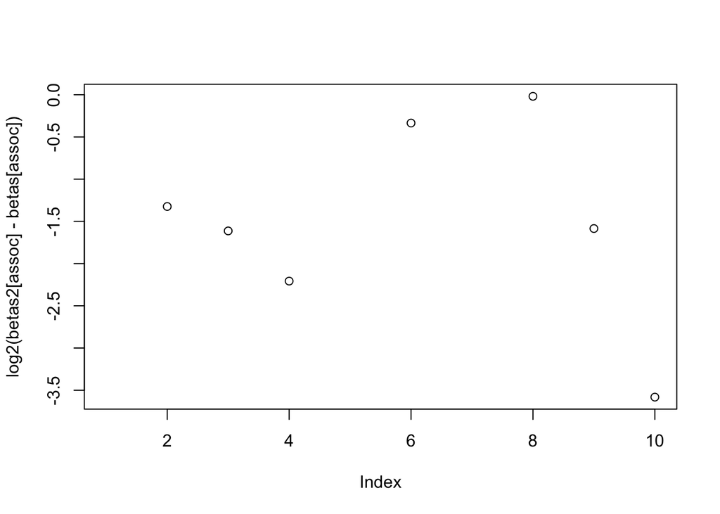

```r
plot(log2(betas2[assoc]-betas[assoc]))
```

*If the SNP coefficients agree, then modeling as recessive seems to be the correct way to model that given SNP, as adding an extra category does not matter as the dominant allele is masking. When looking at effect sizes of the significant ones, for a lot of the SNPs the effect sizes are quite different between the two models*